# Model Comparison

Zarrar Shehzad

February 17, 2017

We want to understand face representation in the FFA. One hypothesis is that face features based on the shape and texture form a multidimensional space. Another hypothesis is that we form a higher-level model of face features more related to everyday features relevant to us such as gender, age, intelligence and that these features better reflect the underlying variables that cause variation in a person’s face. So low-level shape/texture features might be used to bootstrap a higher level model of age, gender, etc. and this is what is represented in the FFA.

We can test these two models by seeing which better predict activity in the FFA as well as the larger ventral face network.

Note that right now this is a bit messy as I’m assuming the feature data is already loaded.

## 0.1 Setup

Load a bunch of packages and functions.

```r
# Path for my own packages
if (!any(.libPaths() == "/home/zshehzad/R/x86_64-redhat-linux-gnu-library/3.2")) .libPaths(c("/home/zshehzad/R/x86_64-redhat-linux-gnu-library/3.2", .libPaths()))
if (!any(.libPaths() == "/home/zshehzad/R_libs")) .libPaths(c("~/R_libs", .libPaths()))

# General workhorse function
library(plyr)

# Parallelization
suppressMessages(library(doMC))
registerDoMC(24)

# If we were to use ggplot2 and other plotting needs
library(RColorBrewer)
library(ggplot2)
source("/data1/famface01/command/encoding/FirstPass/plot_functions.R")

# This gets us the simple_lm function for faster GLMs
source("/data1/famface01/command/encoding/SubRois_Unfam/lm_functions.R")

## For heatmap.2
#suppressMessages(library(gplots))
## For our own custom convolution
#source("/data1/famface01/command/encoding/ShapesAnalysis/000_funs_load_convolve.R")
```

And some general variable of interest.

```r
subjects <- sprintf("sub%02i", 1:6) # again skipping sub01
#indir    <- "/data1/famface01/analysis/encoding/ShapeAnalysis/data"
rnames   <- c("r.vATL","r.aFFA", "r.pFFA", "r.OFA", "r.EBA", 'r.Amyg',
              "l.vATL", "l.FFA", "l.OFA", "l.EBA", 'l.Amyg')
```

### 0.1.1 Load

#### 0.1.1.1 Predicted/Residual Face Features

Actually first load the predicted/residual face features.

```r
indir <- "/data1/famface01/analysis/misc/320_roi_task_activity"
load(file.path(indir, "20_predict_face_feats.rda"))
vnames <- demo.vnames
```

#### 0.1.1.2 Convolve Features

Second convolve the different features including faces. We only temporarily need to do faces again first due to a previous error.

```r
source("/data1/famface01/command/encoding/ShapesAnalysis/000_funs_load_convolve.R")
suppressMessages(library(bigmemory))

tmpfile <- "/tmp/22_roi_predicts_vs_shapes_convs.rda"
if (file.exists(tmpfile)) {
  load(tmpfile, verbose=T)
} else {
  #dat <- dat.vols$sub01

  system.time(conv.faces <- llply(dat.vols, function(dat) {
    convolve.features.worker(dat$basics$timing, dat$features$face, verbose=F, parallel=F)
  }, .parallel=T))

  system.time(conv.fas <- llply(dat.vols, function(dat) {
    # rearrange/assign
    ref.vnames <- as.character(dat$basics$timing$video)
    fac.scores2 <- matrix(0, length(ref.vnames), ncol(fac.scores))
    for (i in 1:nrow(fac.scores)) {
      inds <- which(ref.vnames == vnames[i])
      if (length(inds) != 2) stop("error")
      fac.scores2[inds,] <- fac.scores[rep(i,2),]
    }

    convs.comps <- convolve.features.byvid(dat$basics, fac.scores2, parallel=F, verbose=F)
    convs.comps
  }, .parallel=T))

  system.time(conv.preds <- llply(dat.vols, function(dat) {
    # rearrange/assign
    ref.vnames <- as.character(dat$basics$timing$video)
    fac.preds2 <- matrix(0, length(ref.vnames), ncol(fac.preds))
    for (i in 1:nrow(fac.scores)) {
      inds <- which(ref.vnames == vnames[i])
      if (length(inds) != 2) stop("error")
      fac.preds2[inds,] <- fac.preds[rep(i,2),]
    }

    convs.comps <- convolve.features.byvid(dat$basics, fac.preds2, parallel=F, verbose=F)
    convs.comps
  }, .parallel=T))

  system.time(conv.resids <- llply(dat.vols, function(dat) {
    # rearrange/assign
    ref.vnames <- as.character(dat$basics$timing$video)
    fac.resids2 <- matrix(0, length(ref.vnames), ncol(fac.resids))
    for (i in 1:nrow(fac.scores)) {
      inds <- which(ref.vnames == vnames[i])
      if (length(inds) != 2) stop("error")
      fac.resids2[inds,] <- fac.resids[rep(i,2),]
    }

    convs.comps <- convolve.features.byvid(dat$basics, fac.resids2, parallel=F, verbose=F)
    convs.comps
  }, .parallel=T))

  # takes 22secs! but is ok cuz have others
  system.time(convs.lows <- llply(dat.vols, function(dat) {
    low.info <- pca.face.feats
    # rearrange/assign
    ref.vnames <- as.character(dat$basics$timing$video)
    low.info2 <- matrix(0, length(ref.vnames), ncol(low.info))
    for (i in 1:nrow(low.info)) {
      inds <- which(ref.vnames == vnames[i])
      if (length(inds) != 2) stop("error")
      low.info2[inds,] <- low.info[rep(i,2),]
    }
    convs.low <- convolve.features.byvid(dat$basics, low.info2, parallel=F, verbose=F)
    convs.low
  }, .parallel=T))

  # get motion
  load.mc <- function(subj) {
    funcdir  <- file.path("/data1/famface01/analysis/preprocessed", subj, "func")
    df.paths <- read.table(file.path(funcdir, "df_paths.txt"), header=T)
    inds     <- df.paths$inindex[df.paths$name == "unfam_vids"]
    fpaths   <- sprintf("%s/mc/func_run%02i_dfile.1D", funcdir, inds)

    mcs <- ldply(fpaths, function(fpath) {
      x <- read.table(fpath)
      x <- as.matrix(x)
      x <- scale(x, scale=F, center=T)
      x
    })
    mcs <- as.matrix(mcs)

    colnames(mcs) <- c("roll", "pitch", "yaw", "dS", "dL", "dP")

    mcs
  }
  lst.mcs <- lapply(subjects, load.mc)
  names(lst.mcs) <- subjects

  # FDs
  load.fds <- function(subj) {
    funcdir  <- file.path("/data1/famface01/analysis/preprocessed", subj, "func")
    df.paths <- read.table(file.path(funcdir, "df_paths.txt"), header=T)
    inds     <- df.paths$inindex[df.paths$name == "unfam_vids"]

    fpaths   <- sprintf("%s/mc/func_run%02i_fd_rel.1D", funcdir, inds)
    fds_rel  <- ldply(fpaths, function(fpath) {
      x <- read.table(fpath)
      x <- as.matrix(x)
      x <- scale(x, scale=F, center=T)
      x
    })
    fds_rel <- as.matrix(fds_rel)

    fpaths   <- sprintf("%s/mc/func_run%02i_fd_abs.1D", funcdir, inds)
    fds_abs  <- ldply(fpaths, function(fpath) {
      x <- read.table(fpath)
      x <- as.matrix(x)
      x <- scale(x, scale=F, center=T)
      x
    })
    fds_abs <- as.matrix(fds_abs)

    cbind(rel=fds_rel, abs=fds_abs)
  }
  lst.fds <- lapply(subjects, load.fds)
  names(lst.fds) <- subjects

  # combine things
  ssubs   <- rep(subjects, sapply(conv.faces, nrow))
  subvars <- model.matrix(~ssubs+0)
  sfaces  <- do.call(rbind, conv.faces)
  sfas    <- do.call(rbind, conv.fas)
  spreds  <- do.call(rbind, conv.preds)
  sresids <- do.call(rbind, conv.resids)
  slows   <- do.call(rbind, convs.lows)
  smcs    <- do.call(rbind, lst.mcs)
  sfds    <- do.call(rbind, lst.fds)
  colnames(sfds) <- c("rel", "abs")

  # these results remove the effect of each subject
  subvars2 <- subvars[,-1]
  sfaces2  <- do.call(rbind, lapply(conv.faces, scale, center=T, scale=F))
  sfas2    <- do.call(rbind, lapply(conv.fas, scale, center=T, scale=F))
  spreds2  <- do.call(rbind, lapply(conv.preds, scale, center=T, scale=F))
  sresids2 <- do.call(rbind, lapply(conv.resids, scale, center=T, scale=F))
  slows2   <- do.call(rbind, lapply(convs.lows, scale, center=T, scale=F))
  smcs2    <- do.call(rbind, lapply(lst.mcs, scale, center=T, scale=F))
  sfds2    <- do.call(rbind, lapply(lst.fds, scale, center=T, scale=F))
  colnames(sfds2) <- c("rel", "abs")

  save(ssubs, subvars, sfaces, sfas, sresids, slows, smcs, sfds, spreds,
       subvars2, sfaces2, sfas2, sresids2, slows2, smcs2, sfds2, spreds2,
       file=tmpfile)
}
```

```
## Loading objects:
##   ssubs
##   subvars
##   sfaces
##   sfas
##   sresids
##   slows
##   smcs
##   sfds
##   spreds
##   subvars2
##   sfaces2
##   sfas2
##   sresids2
##   slows2
##   smcs2
##   sfds2
##   spreds2
```

#### 0.1.1.3 ROI Data

Then first, get the ROI data.

```r
load.cur <- function(subj) {
  indir <- "/data1/famface01/analysis/encoding/ShapeAnalysis/data"
  infile <- sprintf("%s/roi_n_more_%s.rda", indir, subj)
  dat <- NULL
  load(infile)
  dat
}

dat.vols <- lapply(subjects, load.cur)
names(dat.vols) <- subjects
```

#### 0.1.1.4 Average ROI Time-Series

We compile the average of each ROI (for now).

```r
lst.rdats <- lapply(dat.vols, function(dat) {
  rdats <- sapply(dat$fmri$dat, rowMeans)
  rdats
})
rdats <- do.call(rbind, lst.rdats)
```

## 0.2 Regression Analyses

We look at both ANOVA and GLM results.

### 0.2.1 Sample ROI Results

We will look at the results of the right pFFA ROI.

```r
print(rnames[3])
```

```
## [1] "r.pFFA"
```

```r
y <- rdats[,3]
fit  <- aov(y ~ ssubs + smcs + sfds + sfaces + spreds + sresids + slows)
sfit <- summary(fit)
sfit
```

```
##                Df   Sum Sq Mean Sq  F value Pr(>F)
## ssubs           5        0       0    0.000      1
## smcs            6   807114  134519   41.414 <2e-16 ***
## sfds            2   995297  497649  153.210 <2e-16 ***
## sfaces          1  7505853 7505853 2310.816 <2e-16 ***
## spreds         18   979077   54393   16.746 <2e-16 ***
## sresids        18   803064   44615   13.735 <2e-16 ***
## slows         265  3690327   13926    4.287 <2e-16 ***
## Residuals   30212 98132783    3248
## ---
## Signif. codes:  0 '***' 0.001 '**' 0.01 '*' 0.05 '.' 0.1 ' ' 1
```

We note several points from the above results:

- First, the predicted factors has a higher Fstat than the lower-level face features (slows).
- The higher predicted factor Fstat might be driven by the much higher Df for the low-level features, meaning that most of the variance could be just in the first few features and so we are penalizing these set of features a lot more than needed. Note that the total SS is higher for the low-level features.
- The F-stats for the framewise displacement (FD) and 6 motion parameters (mcs) are much higher than the effects of interest. This seems like it should be a concern.
- The face response is very robust.

### 0.2.2 Reducing DFs of Low-Level Features

We take the top 18 PCA components to reduce the DF for the low-level features. Note that the Fstat does go up but not by that much.

```r
pca.slows <- prcomp(slows2, retx=T)$x
top.pca.slows <- pca.slows[,1:18]
fit  <- aov(y ~ ssubs + smcs + sfds + sfaces + spreds + sresids + top.pca.slows)
sfit <- summary(fit)
sfit
```

```
##                  Df    Sum Sq Mean Sq  F value   Pr(>F)
## ssubs             5         0       0    0.000        1
## smcs              6    807114  134519   40.366  < 2e-16 ***
## sfds              2    995297  497649  149.332  < 2e-16 ***
## sfaces            1   7505853 7505853 2252.315  < 2e-16 ***
## spreds           18    979077   54393   16.322  < 2e-16 ***
## sresids          18    803064   44615   13.388  < 2e-16 ***
## top.pca.slows    18    318323   17685    5.307 1.53e-12 ***
## Residuals     30459 101504787    3333
## ---
## Signif. codes:  0 '***' 0.001 '**' 0.01 '*' 0.05 '.' 0.1 ' ' 1
```

### 0.2.3 Looking at all the ROIs

In almost all of the ROIs, the predicted trait scores fit the ROI data better than the residuals or the low-level features, except in the vATL and the EBA. In the EBA, the residuals offer a better fit suggesting there’s something we aren’t fitting with our data that’s useful in that region.

```r
fit  <- aov(rdats ~ ssubs + smcs + sfds + sfaces + spreds + sresids + slows)
sfit <- summary(fit)
sfit
```

```
##  Response r.vATL :
##                Df   Sum Sq Mean Sq  F value    Pr(>F)
## ssubs           5        0       0   0.0000  1.000000
## smcs            6   335876   55979  17.5982 < 2.2e-16 ***
## sfds            2   820826  410413 129.0214 < 2.2e-16 ***
## sfaces          1   516653  516653 162.4202 < 2.2e-16 ***
## spreds         18   128936    7163   2.2519  0.001774 **
## sresids        18   236069   13115   4.1229 8.890e-09 ***
## slows         265  1360994    5136   1.6145 1.095e-09 ***
## Residuals   30212 96103407    3181
## ---
## Signif. codes:  0 '***' 0.001 '**' 0.01 '*' 0.05 '.' 0.1 ' ' 1
##
##  Response r.aFFA :
##                Df   Sum Sq Mean Sq   F value Pr(>F)
## ssubs           5        0       0    0.0000      1
## smcs            6   281685   46948   21.0321 <2e-16 ***
## sfds            2   374494  187247   83.8852 <2e-16 ***
## sfaces          1  3314157 3314157 1484.7141 <2e-16 ***
## spreds         18   397881   22104    9.9026 <2e-16 ***
## sresids        18   296491   16472    7.3792 <2e-16 ***
## slows         265  1744087    6581    2.9484 <2e-16 ***
## Residuals   30212 67438786    2232
## ---
## Signif. codes:  0 '***' 0.001 '**' 0.01 '*' 0.05 '.' 0.1 ' ' 1
##
##  Response r.pFFA :
##                Df   Sum Sq Mean Sq   F value Pr(>F)
## ssubs           5        0       0    0.0000      1
## smcs            6   807114  134519   41.4142 <2e-16 ***
## sfds            2   995297  497649  153.2104 <2e-16 ***
## sfaces          1  7505853 7505853 2310.8161 <2e-16 ***
## spreds         18   979077   54393   16.7459 <2e-16 ***
## sresids        18   803064   44615   13.7354 <2e-16 ***
## slows         265  3690327   13926    4.2873 <2e-16 ***
## Residuals   30212 98132783    3248
## ---
## Signif. codes:  0 '***' 0.001 '**' 0.01 '*' 0.05 '.' 0.1 ' ' 1
##
##  Response r.OFA :
```

[output cut: 87 more lines]

```
## ---
## Signif. codes:  0 '***' 0.001 '**' 0.01 '*' 0.05 '.' 0.1 ' ' 1
##
##  Response l.Amyg :
##                Df    Sum Sq Mean Sq F value    Pr(>F)
## ssubs           5         0       0  0.0000   1.00000
## smcs            6   2847954  474659 83.7949 < 2.2e-16 ***
## sfds            2    322520  161260 28.4684 4.446e-13 ***
## sfaces          1     17949   17949  3.1686   0.07508 .
## spreds         18    282298   15683  2.7687 8.069e-05 ***
## sresids        18    181006   10056  1.7752   0.02231 *
## slows         265   2296708    8667  1.5300 7.007e-08 ***
## Residuals   30212 171136933    5665
## ---
## Signif. codes:  0 '***' 0.001 '**' 0.01 '*' 0.05 '.' 0.1 ' ' 1
```

### 0.2.4 Individual Variables

We can pop the hood and see what specific variables in the predicted trait scores are important in related to the ROI timeseries data. We make this easier by removing some other sets of variables.

```r
fit  <- lm(y ~ ssubs + smcs + sfds + sfaces + spreds)
sfit <- summary(fit)
sfit
```

```
##
## Call:
## lm(formula = y ~ ssubs + smcs + sfds + sfaces + spreds)
##
## Residuals:
##     Min      1Q  Median      3Q     Max
## -713.23  -36.03    0.31   36.21  322.31
##
## Coefficients:
##             Estimate Std. Error t value Pr(>|t|)
## (Intercept) -27.1060     0.9940 -27.270  < 2e-16 ***
## ssubssub02    0.2876     1.1503   0.250  0.80258
## ssubssub03   -0.1723     1.1503  -0.150  0.88095
## ssubssub04   -0.1239     1.1502  -0.108  0.91422
## ssubssub05   -0.1436     1.1502  -0.125  0.90067
## ssubssub06   -0.1049     1.1502  -0.091  0.92736
## smcsroll      3.8407     6.9435   0.553  0.58018
## smcspitch     6.1082     2.9344   2.082  0.03739 *
## smcsyaw      26.6192     5.8799   4.527 6.00e-06 ***
## smcsdS        6.3395     3.3499   1.892  0.05844 .
## smcsdL       -5.5609    10.5513  -0.527  0.59818
## smcsdP       81.1541     5.6916  14.259  < 2e-16 ***
## sfdsrel     106.0327     6.4777  16.369  < 2e-16 ***
## sfdsabs     -17.7573     3.9478  -4.498 6.89e-06 ***
## sfaces       57.4996     1.2182  47.200  < 2e-16 ***
## spreds1      -2.5104     1.0008  -2.508  0.01214 *
## spreds2      -1.5062     1.0741  -1.402  0.16084
## spreds3      -8.2626     1.1215  -7.367 1.78e-13 ***
## spreds4      -4.5475     1.0060  -4.521 6.19e-06 ***
## spreds5       5.5406     1.0850   5.106 3.30e-07 ***
## spreds6       1.6239     1.0139   1.602  0.10926
## spreds7       0.3111     1.3763   0.226  0.82115
## spreds8       0.2176     1.3769   0.158  0.87443
## spreds9      -6.4545     1.0400  -6.206 5.50e-10 ***
## spreds10     -1.0047     0.9831  -1.022  0.30679
## spreds11      3.3779     1.2243   2.759  0.00580 **
## spreds12      3.4494     1.2205   2.826  0.00471 **
## spreds13      2.2121     1.5924   1.389  0.16479
## spreds14      0.8664     1.1372   0.762  0.44615
## spreds15      2.1304     1.0155   2.098  0.03593 *
## spreds16      0.1480     0.9519   0.156  0.87642
## spreds17     -5.1941     1.2146  -4.276 1.91e-05 ***
## spreds18     -4.0676     1.0515  -3.868  0.00011 ***
## ---
## Signif. codes:  0 '***' 0.001 '**' 0.01 '*' 0.05 '.' 0.1 ' ' 1
##
## Residual standard error: 58.01 on 30495 degrees of freedom
## Multiple R-squared:  0.09111,    Adjusted R-squared:  0.09015
## F-statistic: 95.53 on 32 and 30495 DF,  p-value: < 2.2e-16
```

Well thhe results above are more promising. Many of the predicted face factor regressors are signficant so it might be that including all of them together reduces the fit or reduces the appearance of a fit.

Below are the loadings from the face factors. The most significant fit (F=-7) is factor 3 and is related to age. The next one was #9 (F=-6) is related to being humble and #5 (F=5) is related to trustworthiness (those 2 seem related). Then #4 => typical (F=-4.5), and then we have #17 and #18 but these appear distributed across items.

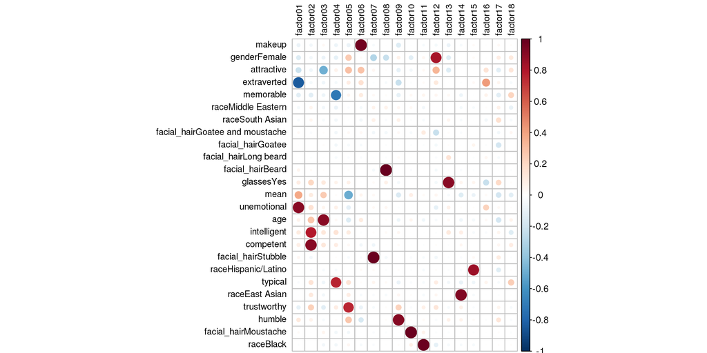

```r
library(corrplot)
hc1     <- hclust(dist(fac.loads))
hc1     <- as.dendrogram(hc1)
ord.hc1 <- order.dendrogram(hc1)
loading <- fac.loads[ord.hc1,]
col <- rev(colorRampPalette(c("#67001F", "#B2182B", "#D6604D",
                              "#F4A582", "#FDDBC7", "#FFFFFF", "#D1E5F0", "#92C5DE",
                              "#4393C3", "#2166AC", "#053061"))(200))
corrplot(loading, tl.col='black', tl.cex=.75, diag=T, col=col, is.corr=T)
```

## 0.3 Visualize Fits

Let’s try to to plot the fits.

In general, we can see the the fit isn’t really too bad. Adding stuff on the face regressors, helps at some points. And there are some points where the fit gets terrible. Maybe some type of attention effect there?

We try four different models, adding on more variables. For each model we see the fitted response on the data.

```r
y <- rdats[,3]

# Fits
fit1  <- lm(y ~ ssubs + smcs + sfds + sfaces)
fit2  <- lm(y ~ ssubs + smcs + sfds + sfaces + spreds)
fit3  <- lm(y ~ ssubs + smcs + sfds + sfaces + spreds + sresids)
fit4  <- lm(y ~ ssubs + smcs + sfds + sfaces + spreds + sresids + slows)

# Adjusted R2
print(summary(fit1)$adj.r.squared) # base
```

```
## [1] 0.08201611
```

```r
print(summary(fit2)$adj.r.squared) # add predicted factors
```

```
## [1] 0.09015439
```

```r
print(summary(fit3)$adj.r.squared) # add residuals factors
```

```
## [1] 0.0967409
```

```r
print(summary(fit4)$adj.r.squared) # add low-level factors
```

```
## [1] 0.1218416
```

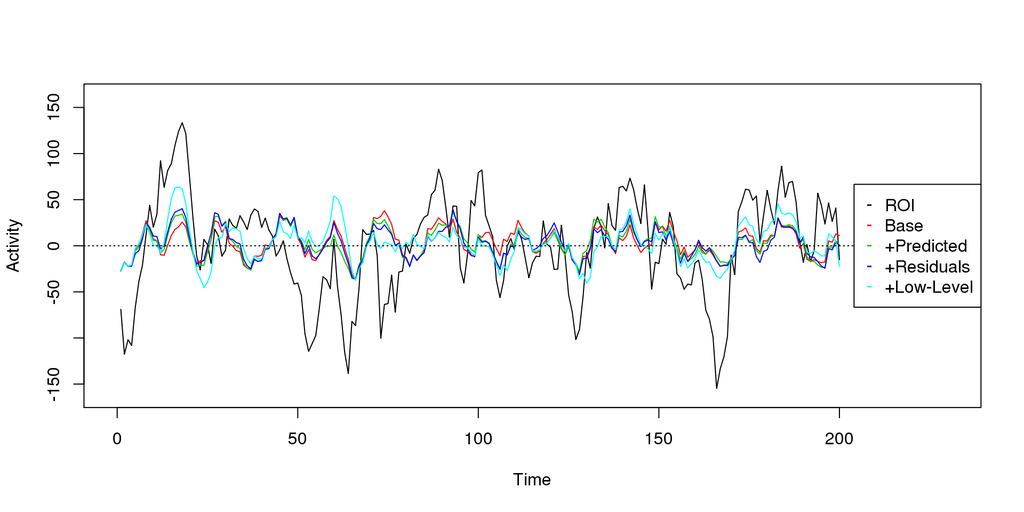

```r
#
tdat  <- cbind(y,fit1$fitted.values,fit2$fitted.values,fit3$fitted.values,fit4$fitted.values)
#tdat2 <- scale(tdat)[1:200,]
tdat2 <- tdat[1:200,]
xlims <- range(c(0:200)) + c(0,30)
ylims <- c(-1,1) * max(abs(tdat2)) * 1.05
plot.ts(tdat2, plot.type="single", col=1:5, ylab="Activity", ylim=ylims, xlim=xlims)
abline(h=0, lty=3)
legend("right", legend=c("ROI", "Base", "+Predicted", "+Residuals", "+Low-Level"), col=1:5, pch="-")
```

Let’s just look at base model and adding the predicted regressors.

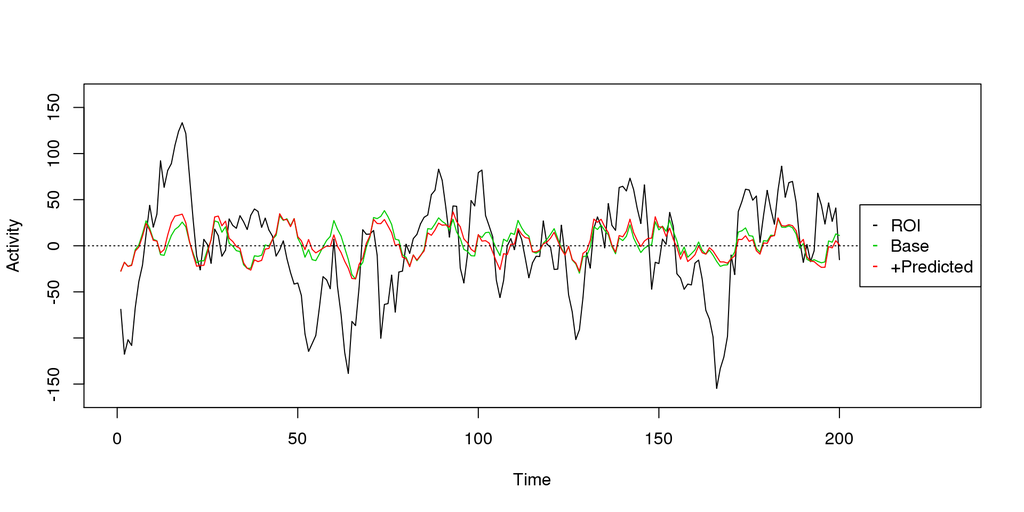

```r
#
tdat  <- cbind(y,fit1$fitted.values,fit2$fitted.values)
#tdat2 <- scale(tdat)[1:200,]
tdat2 <- tdat[1:200,]
xlims <- range(c(0:200)) + c(0,30)
ylims <- c(-1,1) * max(abs(tdat2)) * 1.05
plot.ts(tdat2, plot.type="single", col=c(1,3,2), ylab="Activity", ylim=ylims, xlim=xlims)
abline(h=0, lty=3)
legend("right", legend=c("ROI", "Base", "+Predicted"), col=c(1,3,2), pch="-")
```

And what do the residuals look like? If the residuals also look like signal (which they do), then suggesting that we aren’t capturing a lot of the data. So here we compare the actual data with the fitted values and the residuals.

```r
cat("r(fitting) =", cor(y, fit2$fitted.values), "\n")
```

```
## r(fitting) = 0.3018413
```

```r
cat("r(residuals) =", cor(y, fit2$residuals), "\n")
```

```
## r(residuals) = 0.9533582
```

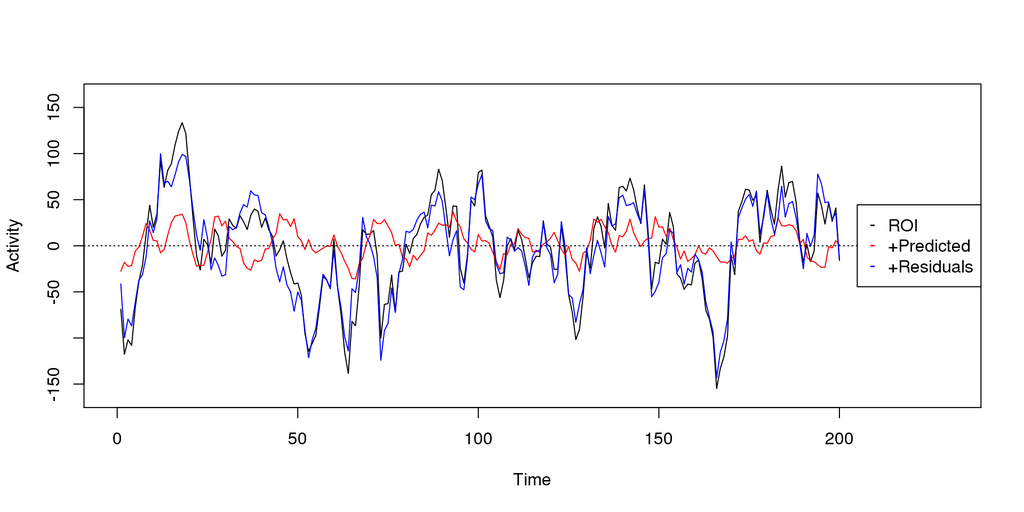

```r
tdat <- cbind(y, fit2$fitted.values, fit2$residuals)
#tdat2 <- scale(tdat)[1:200,]
tdat2 <- tdat[1:200,]
xlims <- range(c(0:200)) + c(0,30)
ylims <- c(-1,1) * max(abs(tdat2)) * 1.05
plot.ts(tdat2, plot.type="single", col=c(1,2,4), ylab="Activity", ylim=ylims, xlim=xlims)
abline(h=0, lty=3)
legend("right", legend=c("ROI", "+Predicted", "+Residuals"), col=c(1,2,4), pch="-")
```

## 0.4 Improving Fit

I could try using lagged versions of the regressor to improve the fit. Nope the lag isn’t what’s doing it.

```r
mat <- model.matrix(~ssubs + smcs + sfds + sfaces + spreds)
mat2 <- cbind(mat[,1:14], mat[,15:ncol(mat)], rbind(0, diff(mat[,15:ncol(mat)], lag=1)), rbind(0, 0,  diff(mat[,15:ncol(mat)], lag=2)))
mat3 <- cbind(mat[,1:14], mat[,15:ncol(mat)], rbind(0, 0, diff(mat[,15:ncol(mat)], lag=2)), rbind(0, 0, 0, 0,  diff(mat[,15:ncol(mat)], lag=4)))
fit1  <- lm(y ~ mat)
fit2  <- lm(y ~ mat2)
fit3  <- lm(y ~ mat3)

cat("r(fitting1) =", cor(y, fit1$fitted.values), "\n")
```

```
## r(fitting1) = 0.3018413
```

```r
cat("r(fitting2) =", cor(y, fit2$fitted.values), "\n")
```

```
## r(fitting2) = 0.3217058
```

```r
cat("r(fitting3) =", cor(y, fit3$fitted.values), "\n")
```

```
## r(fitting3) = 0.3251848
```

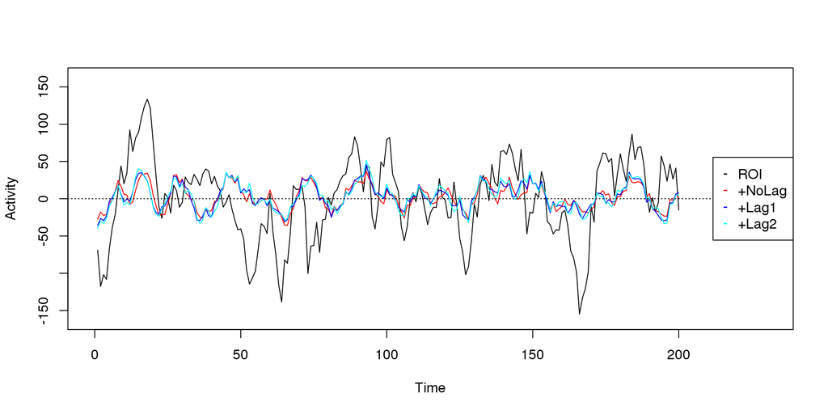

```r
tdat <- cbind(y, fit1$fitted.values, fit2$fitted.values, fit3$fitted.values)
tdat2 <- tdat[1:200,]
xlims <- range(c(0:200)) + c(0,30)
ylims <- c(-1,1) * max(abs(tdat2)) * 1.05
plot.ts(tdat2, plot.type="single", col=c(1,2,4,5), ylab="Activity", ylim=ylims, xlim=xlims)
abline(h=0, lty=3)
legend("right", legend=c("ROI", "+NoLag", "+Lag1", "+Lag2"), col=c(1,2,4,5), pch="-")
```

What if we doing a moving window regression? Might there be certain windows that are better? We restrict the whole thing to the 200 timepoints. Oh this fit is better.

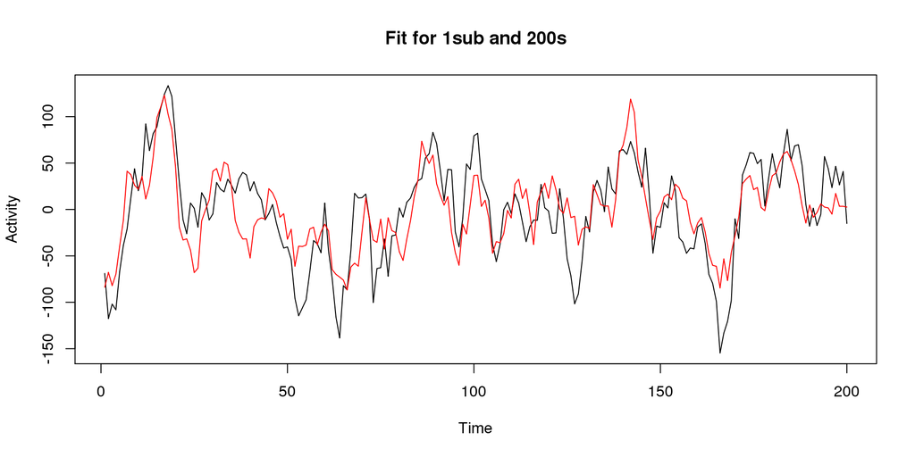

```r
mat <- model.matrix(~ssubs + smcs + sfds + sfaces + spreds)

mat0 <- mat[1:200,-c(2:6)] # don't need ssubs
y0 <- y[1:200]

# Try whole window
fit0  <- lm(y0 ~ mat0)
plot.ts(cbind(y0, fit0$fitted.values), plot.type="single", ylab="Activity", col=1:2, main="Fit for 1sub and 200s")
```

```r
cor(cbind(y0, fit0$fitted.values))[1,2]
```

```
## [1] 0.756806
```

Hmm so that works, maybe it is because I’m looking at one subject now and not just the this time segment.

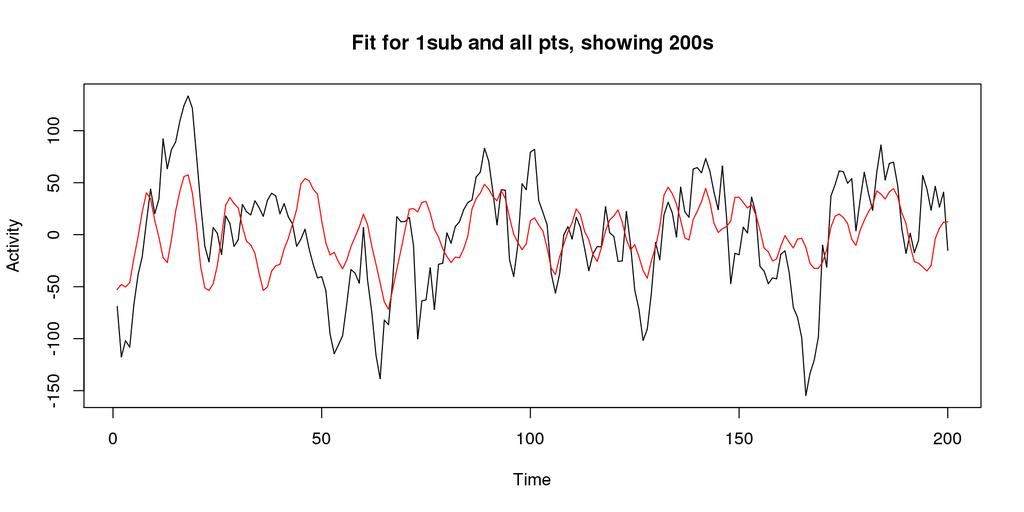

```r
mat0 <- mat[ssubs=='sub01',-c(2:6)] # don't need ssubs
y0 <- y[ssubs=='sub01']

# Try subject
fit0  <- lm(y0 ~ mat0)
plot.ts(cbind(y0, fit0$fitted.values)[1:200,], plot.type="single", ylab="Activity", col=1:2, main="Fit for 1sub and all pts, showing 200s")
```

```r
cor(cbind(y0, fit0$fitted.values)[1:200,])[1,2]
```

```
## [1] 0.4916672
```

It’s a bit of both, looking at the fit now when reducing the window to 50tpts (50s).

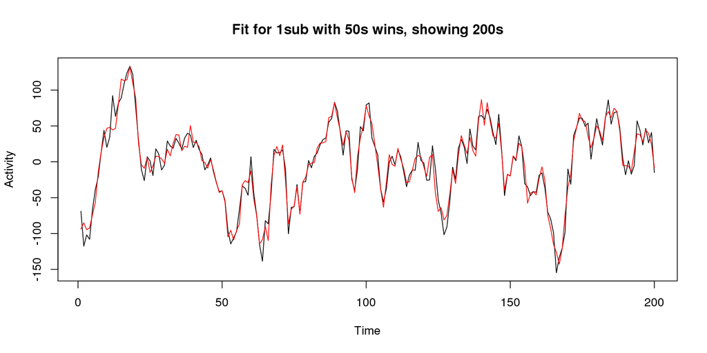

```r
mat <- model.matrix(~ssubs + smcs + sfds + sfaces + spreds)
mat0 <- mat[1:200,-c(2:6)] # don't need ssubs
y0 <- y[1:200]
# Try chunks of 50
fits  <- lapply(seq(0,150,by=50), function(ti) {
  tinds <- (ti+1):(ti+50)
  lm(y0[tinds] ~ mat0[tinds,])
})
fitvals <- unlist(lapply(fits, function(fit) fit$fitted.values))
# Plot
plot.ts(cbind(y0, fitvals), plot.type="single", ylab="Activity", col=1:2, main="Fit for 1sub with 50s wins, showing 200s")
```

```r
cor(cbind(y0, fitvals))[1,2]
```

```
## [1] 0.9745118
```